# Intro to Data Analysis with R: Exercise 2 Solutions

UCI Data Science Initiative

## Introduction

This set of exercises picks up where we left off with the Auto MPG data in Exercise 1. We now focus on exploratory data analysis.

### Part A

**A.1** Open a new R script and save it in the directory you created in Part A.1 of Exercise 1. Then, load the Auto MPG data set with the additional variable `diesel` using the `load()` function and file path from the end of Exercise 1.

```r
load(here::here("data", "auto_mpg_v2.Rda"))
```

**A.2** Using the `summary()` function, look at descriptive statistics for the Auto MPG data. What do you notice?

```r
summary(auto)
```

```
##       mpg        cyl          disp             hp             weight
##  Min.   : 9.00   3:  4   Min.   : 68.0   Min.   : 46.00   Min.   :1613
##  1st Qu.:17.50   4:207   1st Qu.:105.0   1st Qu.: 75.75   1st Qu.:2226
##  Median :23.00   5:  3   Median :151.0   Median : 95.00   Median :2822
##  Mean   :23.51   6: 84   Mean   :194.8   Mean   :105.08   Mean   :2979
##  3rd Qu.:29.00   8:108   3rd Qu.:302.0   3rd Qu.:130.00   3rd Qu.:3618
##  Max.   :46.60           Max.   :455.0   Max.   :230.00   Max.   :5140
##  NA's   :8                               NA's   :6
##       acc           model.yr         origin          name
##  Min.   : 8.00   Min.   :70.00   Min.   :1.000   Length:406
##  1st Qu.:13.70   1st Qu.:73.00   1st Qu.:1.000   Class :character
##  Median :15.50   Median :76.00   Median :1.000   Mode  :character
##  Mean   :15.52   Mean   :75.92   Mean   :1.569
##  3rd Qu.:17.18   3rd Qu.:79.00   3rd Qu.:2.000
##  Max.   :24.80   Max.   :82.00   Max.   :3.000
##
##  diesel
##  0:399
##  1:  7
##
##
##
##
##
```

### Part B

**B.1** Plot a relative frequency histogram of the response variable, MPG. Color the boxes grey. Make sure to name the plot and axes.

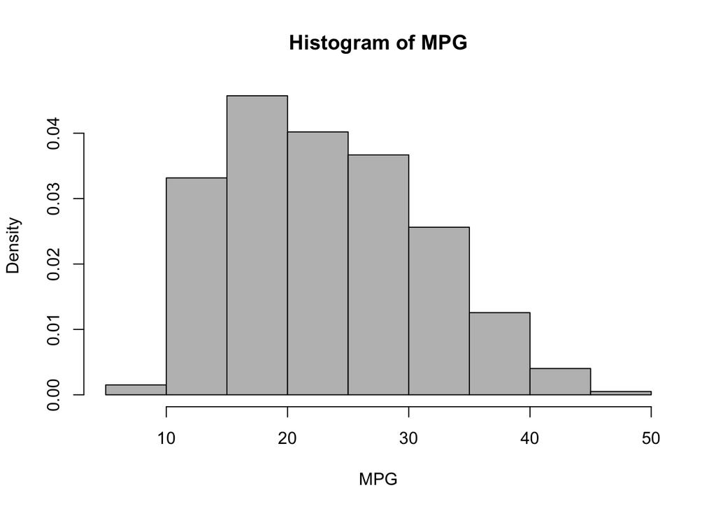

```r
hist(auto$mpg, freq=FALSE, col = "grey", main = "Histogram of MPG", xlab = "MPG")
```

**B.2** Add a density curve to the histogram you plotted in B.1 using the `lines()` and `density()` functions. Color it red using the `col` argument. HINT: You need to change the value of `na.rm` in the density function to avoid an error. You also need to make sure that the histogram is on the proper scale!

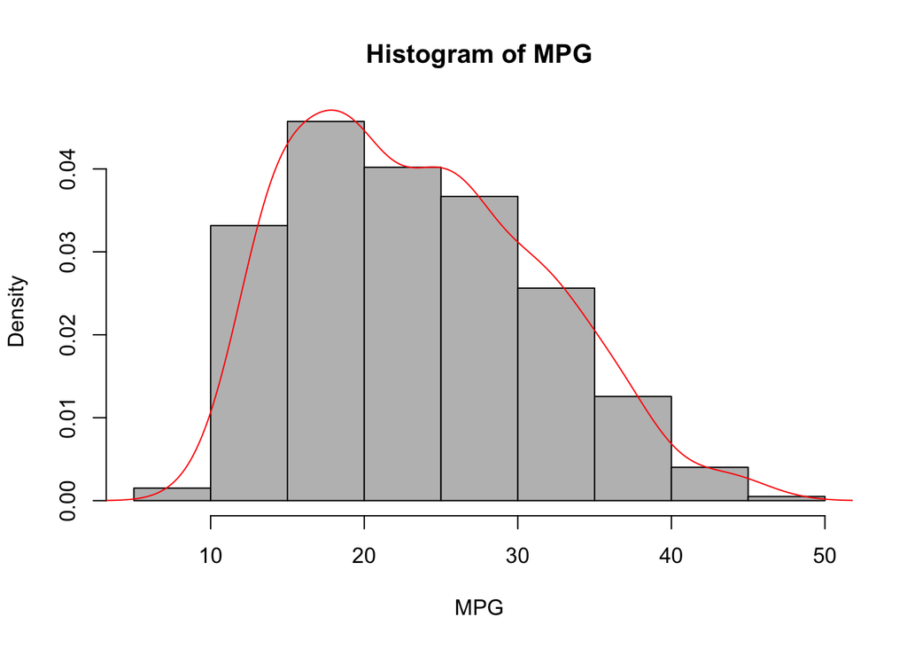

```r
hist(auto$mpg, freq=FALSE, col = "grey", main = "Histogram of MPG", xlab = "MPG")
lines(density(auto$mpg, na.rm=TRUE), col="red")
```

**B.3** Add a vertical line to the plot from B.2 at the median of MPG. Make it dashed using the `lty` arguement, and make it red. HINT: You may need to use `na.rm` again.

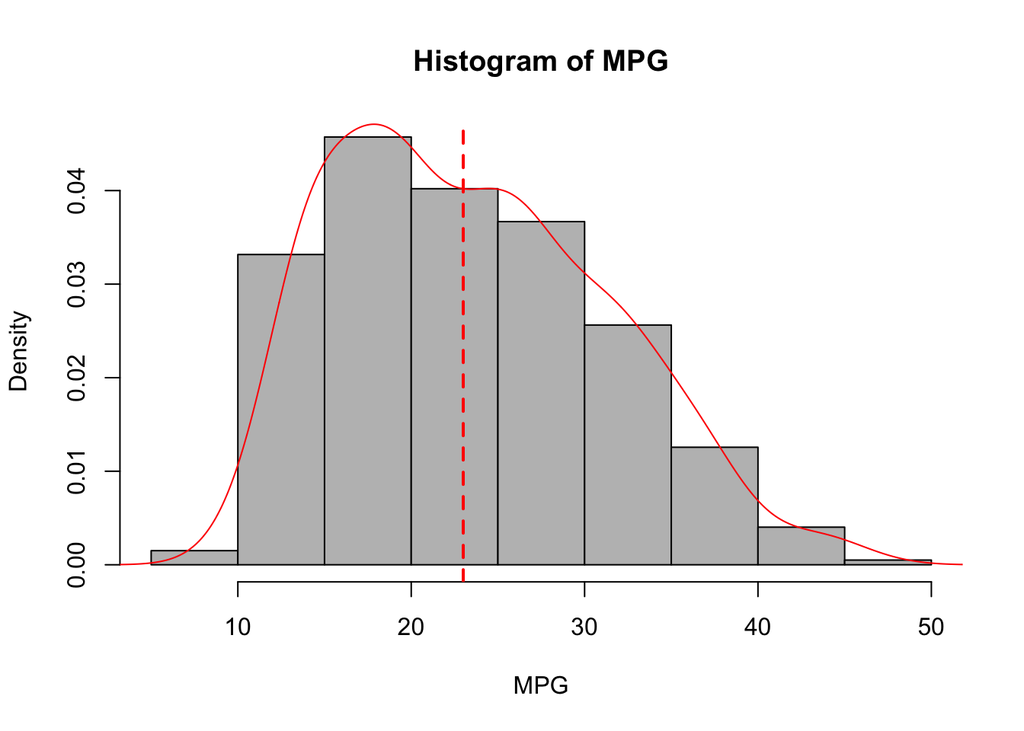

```r
hist(auto$mpg, freq=FALSE, col = "grey", main = "Histogram of MPG", xlab = "MPG")
lines(density(auto$mpg, na.rm=TRUE), col="red", main="Densities of Samp1 and Samp2", xlab="")
abline(v = median(auto$mpg, na.rm=TRUE), col = "red", lwd = 2, lty=2)
```

### Part C

Create a boxplot of MPG grouped by the number of cylinders. Color the boxes grey. Make sure to name the plot and axes.

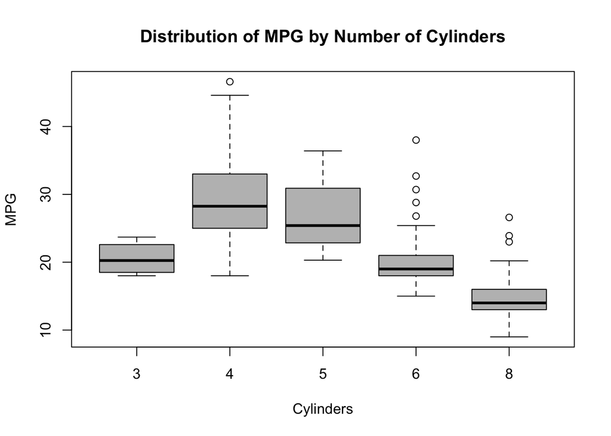

```r
boxplot(mpg ~ cyl, data = auto, col = "grey",
        main = "Distribution of MPG by Number of Cylinders",
        xlab = "Cylinders", ylab = "MPG")
```

### Part D

Create a scatterplot matrix of the Auto MPG data. Include the following variables: “mpg”, “cyl”, “disp”, “hp”, “weight”, “acc”, “model.yr”. What relationships do you see? Is there any confounding? Which variables should be included in a regression?

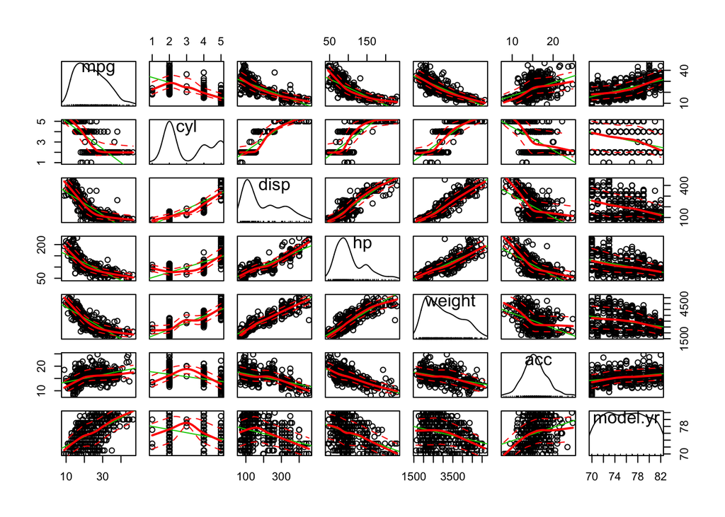

```r
library(car)
scatterplotMatrix( auto[, c("mpg", "cyl", "disp", "hp", "weight", "acc", "model.yr")] )
```